# 케글 대출고객 분석

BBJ

2022-08-08

#### 대출고객 분석 파일 데이터프레임으로 불러오기

```r
loanDF <- read.csv('./Loan payments data.csv', header = T)
# View(loanDF)
tail(loanDF, 15)
```

```
##         Loan_ID        loan_status Principal terms effective_date   due_date
## 486 xqd20160486 COLLECTION_PAIDOFF      1000    30      9/12/2016 10/11/2016
## 487 xqd20160487 COLLECTION_PAIDOFF       800    15      9/12/2016  9/26/2016
## 488 xqd20160488 COLLECTION_PAIDOFF      1000    30      9/12/2016 10/11/2016
## 489 xqd20160489 COLLECTION_PAIDOFF      1000    15      9/12/2016  9/26/2016
## 490 xqd20160490 COLLECTION_PAIDOFF      1000    30      9/12/2016 10/11/2016
## 491 xqd20160491 COLLECTION_PAIDOFF      1000    30      9/12/2016 10/11/2016
## 492 xqd20160492 COLLECTION_PAIDOFF      1000    30      9/12/2016 10/11/2016
## 493 xqd20160493 COLLECTION_PAIDOFF      1000    30      9/12/2016 10/11/2016
## 494 xqd20160494 COLLECTION_PAIDOFF      1000    15      9/12/2016  9/26/2016
## 495 xqd20160495 COLLECTION_PAIDOFF      1000    30      9/12/2016 10/11/2016
## 496 xqd20160496 COLLECTION_PAIDOFF      1000    30      9/12/2016 10/11/2016
## 497 xqd20160497 COLLECTION_PAIDOFF      1000    15      9/12/2016  9/26/2016
## 498 xqd20160498 COLLECTION_PAIDOFF       800    15      9/12/2016  9/26/2016
## 499 xqd20160499 COLLECTION_PAIDOFF      1000    30      9/12/2016 11/10/2016
```

[output cut: 17 more lines]

```r
str(loanDF[sample(1:nrow(loanDF),10),]) # 데이터프레임 랜덤으로 보여주기
```

```
## 'data.frame':    10 obs. of  11 variables:
##  $ Loan_ID       : chr  "xqd20160278" "xqd20160270" "xqd20160243" "xqd20160038" ...
##  $ loan_status   : chr  "PAIDOFF" "PAIDOFF" "PAIDOFF" "PAIDOFF" ...
##  $ Principal     : int  1000 800 800 700 1000 1000 300 1000 1000 1000
##  $ terms         : int  30 30 15 15 30 30 7 30 30 30
##  $ effective_date: chr  "9/14/2016" "9/14/2016" "9/12/2016" "9/11/2016" ...
##  $ due_date      : chr  "10/13/2016" "10/13/2016" "9/26/2016" "9/25/2016" ...
##  $ paid_off_time : chr  "10/13/2016 9:00" "10/6/2016 12:09" "9/26/2016 23:00" "9/25/2016 13:00" ...
##  $ past_due_days : int  NA NA NA NA NA NA NA NA 61 NA
##  $ age           : int  31 40 36 33 44 29 29 40 33 19
##  $ education     : chr  "college" "college" "Bechalor" "High School or Below" ...
##  $ Gender        : chr  "male" "female" "male" "male" ...
```

```r
# str(loanDF)
```

### 정보 및 컬럼들의 타입 확인

```r
summary(loanDF)
```

```
##    Loan_ID          loan_status          Principal          terms
##  Length:500         Length:500         Min.   : 300.0   Min.   : 7.00
##  Class :character   Class :character   1st Qu.:1000.0   1st Qu.:15.00
##  Mode  :character   Mode  :character   Median :1000.0   Median :30.00
##                                        Mean   : 943.2   Mean   :22.82
##                                        3rd Qu.:1000.0   3rd Qu.:30.00
##                                        Max.   :1000.0   Max.   :30.00
##
##  effective_date       due_date         paid_off_time      past_due_days
##  Length:500         Length:500         Length:500         Min.   : 1.00
##  Class :character   Class :character   Class :character   1st Qu.: 3.00
##  Mode  :character   Mode  :character   Mode  :character   Median :37.00
##                                                           Mean   :36.01
##                                                           3rd Qu.:60.00
##                                                           Max.   :76.00
##                                                           NA's   :300
##       age         education            Gender
##  Min.   :18.00   Length:500         Length:500
##  1st Qu.:27.00   Class :character   Class :character
##  Median :30.00   Mode  :character   Mode  :character
##  Mean   :31.12
##  3rd Qu.:35.00
##  Max.   :51.00
##
```

```r
# Class :character를 factor로 바꾸라는데 안바꿔도 되긴하는데? 왜?
```

### 불필요한 변수 제거

```r
nrow(loanDF) # loanDF 몇 행인가?
```

```
## [1] 500
```

```r
length(unique(loanDF$Loan_ID)) # 500, 전부다 다른 유니크값
```

```
## [1] 500
```

```r
# loanDF <- loanDF %>% select(-Loan_ID)
# head(loanDF)
```

### 결측치 개수 및 분포 확인, 결측지 처리

- loan_status : 대출 상환 유무
- PAIDOFF : 상환 기간 내 채무 이행, COLLECTION : 채무 불이행(연체), COLLECTION_PAIDOFF : 대출금 상환 만기 후 상환 완료
- paid_off time : 고객이 기간 내 상환한 날짜, past_due_days : 만기 후 지난 대출 기간
- 채무 이행자(PAIDOFF)는 past_due_days가 없음.
- 결측치를 통해 추정할 수 있는 상환 기간 내 채무 이행자 : 300명
- 결측치 제거할 필요 없음.

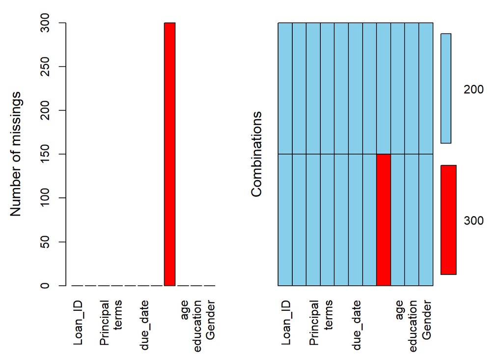

```r
library(VIM) # # Missing values with VIM::aggr()
aggr(loanDF, numbers = T, prop = F)
```

```r
# loanDF[!complete.cases(loanDF), ] # 결측치가 포함되지않은 정보만
head(loanDF[complete.cases(loanDF), ]) # 결측지가 포함된 정보만
```

```
##         Loan_ID loan_status Principal terms effective_date  due_date
## 301 xqd20160301  COLLECTION      1000    15       9/9/2016 9/23/2016
## 302 xqd20160302  COLLECTION      1000    30       9/9/2016 10/8/2016
## 303 xqd20160303  COLLECTION      1000    30       9/9/2016 10/8/2016
## 304 xqd20160304  COLLECTION       800    15       9/9/2016 9/23/2016
## 305 xqd20160305  COLLECTION       800    15       9/9/2016 9/23/2016
## 306 xqd20160306  COLLECTION      1000    15      9/10/2016 9/24/2016
##     paid_off_time past_due_days age            education Gender
## 301                          76  29              college   male
## 302                          61  37 High School or Below   male
## 303                          61  33 High School or Below   male
## 304                          76  27              college   male
## 305                          76  24             Bechalor   male
## 306                          75  31 High School or Below female
```

```r
sum(is.na(loanDF)) # 결측치 개수 확인
```

```
## [1] 300
```

```r
# loanDF$past_due_days <- ifelse(is.na(loanDF$past_due_days), mean(loanDF$past_due_days, na.rm = T), loanDF$past_due_days) # 결측치를 평균으로 채우기, 할 필요 없음.
```

# 대출금과 나이, 상환기간은 관계가 있는가?

- Principal - terms : 양의 상관계수
  - 대출 상환 기관과 대출금은 연관성이 있다. 기관이 길수록 대출금은 오를 수 있음.
- Principal - age : 약한 음의 상관계수
  - 나이와 대출하는 대출금의 영향은 낮음. 개인의 상황에 영향을 받을것으로 추정.

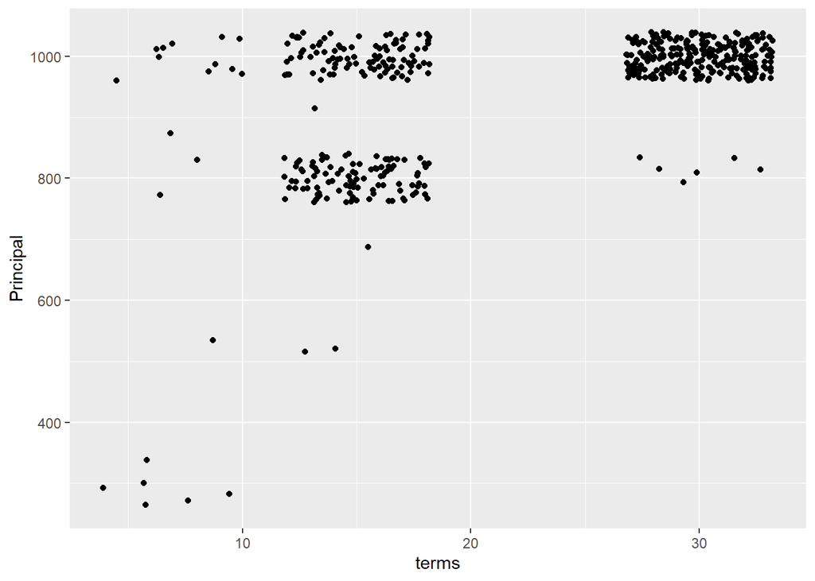

```r
library(ggplot2)
ggplot(data = loanDF, aes(x = terms, y = Principal)) + geom_jitter() # geom_point()
```

```r
cor(loanDF$Principal, loanDF$terms) # 상관관계
```

```
## [1] 0.5343015
```

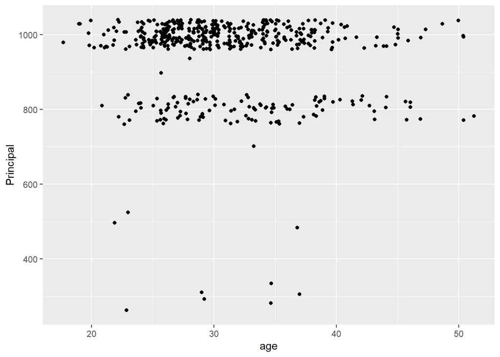

```r
ggplot(data = loanDF, aes(x = age, y = Principal)) + geom_jitter() # geom_jitter()는 흩뿌림.
```

```r
cor(loanDF$Principal, loanDF$age)
```

```
## [1] -0.0926126
```

# 채무 이행별 고객 수 분류

```r
levels(loanDF$loan_status)
```

[output not shown]

```r
table(loanDF$loan_status)
```

```
##
##         COLLECTION COLLECTION_PAIDOFF            PAIDOFF
##                100                100                300
```

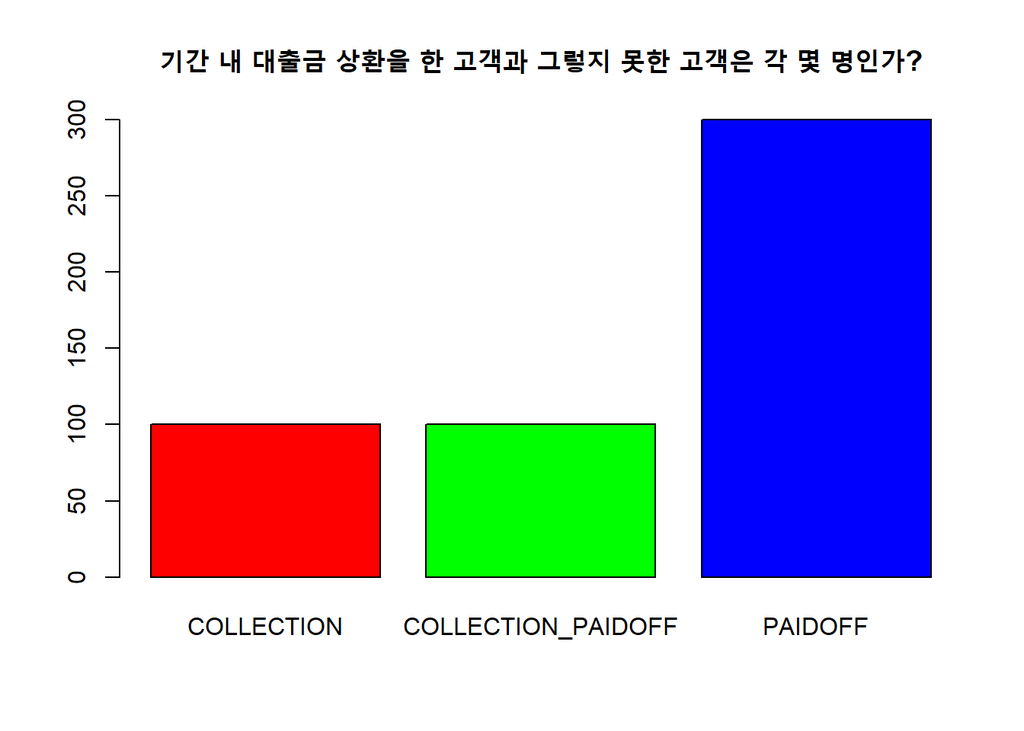

```r
barplot(table(loanDF$loan_status), col = rainbow(3), main = '기간 내 대출금 상환을 한 고객과 그렇지 못한 고객은 각 몇 명인가?')
```

# 대출상환 상태에 따른 대출 대출금의 도수분포 확인

- PAIDOFF, COLLECTION, COLLECTION_PAIDOFF와 Principal
- PAIDOFF는 기간 내 채무 이행을 완료하였으므로 제외해보자

```r
# install.packages("dplyr") # Used for almost all data handling, %>% 사용
# group_by, summarise
library(dplyr)
loan_group <- loanDF %>%
  filter(loan_status %in% c("COLLECTION", "COLLECTION_PAIDOFF")) %>%
  group_by(loan_status, Principal) %>%
  summarise(count = n())
loan_group
```

```
## # A tibble: 5 × 3
## # Groups:   loan_status [2]
##   loan_status        Principal count
##   <chr>                  <int> <int>
## 1 COLLECTION               800    23
## 2 COLLECTION              1000    77
## 3 COLLECTION_PAIDOFF       500     1
## 4 COLLECTION_PAIDOFF       800    19
## 5 COLLECTION_PAIDOFF      1000    80
```

# 그렇다면 고객들이 대출한 돈은 얼마인가?

## *대출금이 많을 수록 기간 내에 갚지 못한다?*

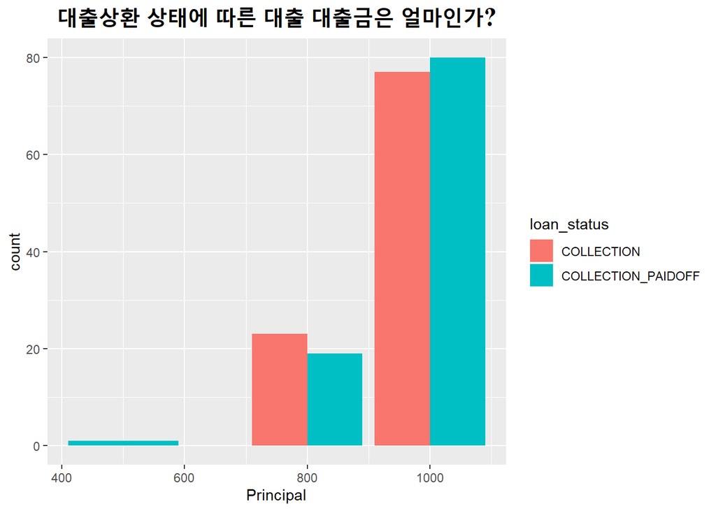

```r
# ggplot으로 해보기
ggplot(data = loan_group, aes(x = Principal, y = count, fill = loan_status)) + geom_bar(stat = "identity", position = "dodge") + ggtitle('대출상환 상태에 따른 대출 대출금은 얼마인가?') +   theme(plot.title = element_text(family = "serif", face = "bold", hjust=0.5, size=18, color='black'))
```

```r
# barplot으로 해보기
table(loanDF$loan_status, loanDF$Principal)
```

```
##
##                      300 500 700 800 900 1000
##   COLLECTION           0   0   0  23   0   77
##   COLLECTION_PAIDOFF   0   1   0  19   0   80
##   PAIDOFF              6   2   1  69   2  220
```

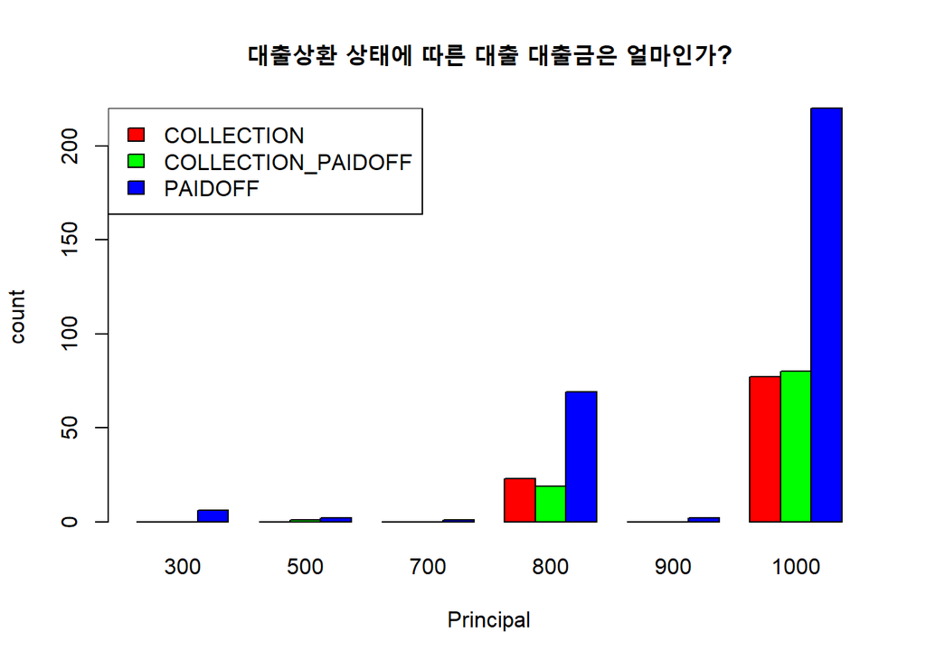

```r
barplot(table(loanDF$loan_status, loanDF$Principal), col=rainbow(3), beside = T, main = '대출상환 상태에 따른 대출 대출금은 얼마인가?', xlab = 'Principal', ylab = 'count')
legend('topleft', legend = c('COLLECTION', 'COLLECTION_PAIDOFF', 'PAIDOFF'), fill = rainbow(3))
```

# 성별에 따른 대출 수

- Principal과 Gender

```r
table(loanDF$Gender)
```

```
##
## female   male
##     77    423
```

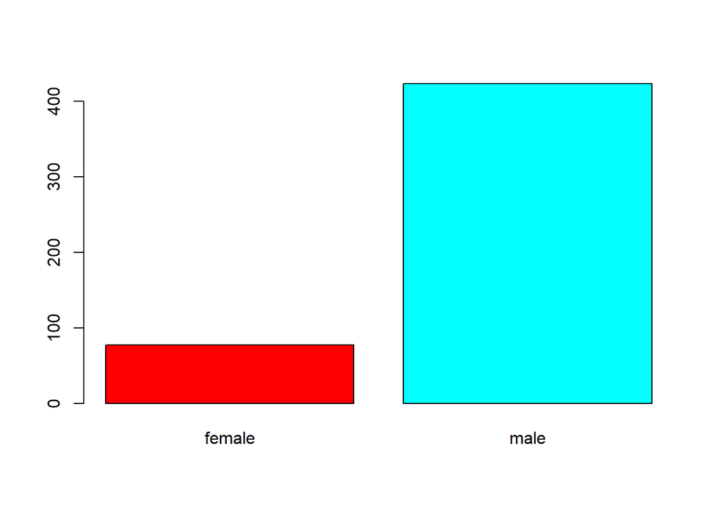

```r
barplot(table(loanDF$Gender), col = rainbow(2))
```

# 대출상환 상태에 따른 성별의 도수분포 확인

```r
# mutate 변환하기
loan_gender <- loanDF %>%
  group_by(loan_status, Gender) %>%
  summarise(count = n()) %>%
  mutate(percent = count / sum(count))
loan_gender
```

```
## # A tibble: 6 × 4
## # Groups:   loan_status [3]
##   loan_status        Gender count percent
##   <chr>              <chr>  <int>   <dbl>
## 1 COLLECTION         female    10   0.1
## 2 COLLECTION         male      90   0.9
## 3 COLLECTION_PAIDOFF female    14   0.14
## 4 COLLECTION_PAIDOFF male      86   0.86
## 5 PAIDOFF            female    53   0.177
## 6 PAIDOFF            male     247   0.823
```

# 그렇다면 대출상환 상태에 따른 성별의 분포는 얼마인가?

- 대출을 압도적으로 많이 한 성별은 남성

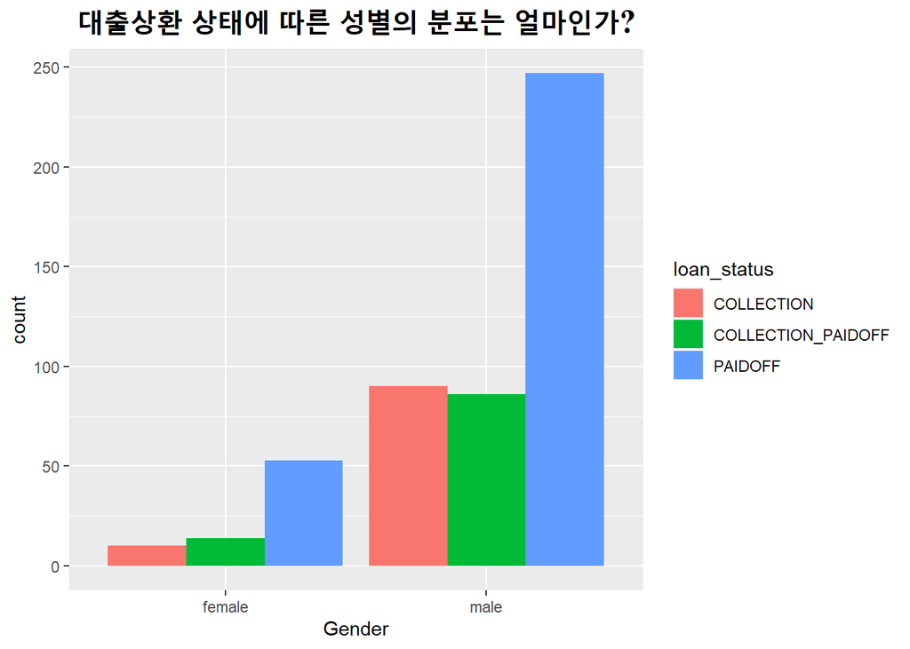

```r
# ggplot으로 해보기
ggplot(data = loan_gender, aes(x = Gender, y = count, fill = loan_status)) + geom_bar(stat = "identity", position = "dodge") + ggtitle('대출상환 상태에 따른 성별의 분포는 얼마인가?') + theme(plot.title = element_text(family = "serif", face = "bold", hjust=0.5, size=18, color='black'))
```

```r
# barplot으로 해보기
table(loanDF$Gender, loanDF$loan_status)
```

```
##
##          COLLECTION COLLECTION_PAIDOFF PAIDOFF
##   female         10                 14      53
##   male           90                 86     247
```

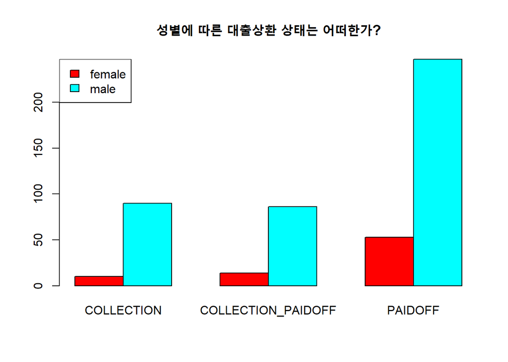

```r
barplot(table(loanDF$Gender, loanDF$loan_status), col = rainbow(2), beside = T, main = '성별에 따른 대출상환 상태는 어떠한가?')
legend('topleft', legend = c('female','male'), fill = rainbow(2))
```